# Supply Side I: Politicians, Campaigns, and Elections

POLISCI 158 · AI & Politics · Session 8 · Monday, October 19, 2026

Simone Paci

## Roadmap

1. Part I: A conversation with Gail Pellerin
   - Explain how AI changes campaign power
2. Part II: What does the evidence establish?
   - Distinguish persuasion from political behavior
3. Part III: Evaluate a rule
   - Trace its mechanism, enforcement and trade-offs

## What would you ask a legislator?

Take one minute. Write a question about an AI election rule.

- What problem does it target?
- How would it work?
- What could it change?

# Part I: A conversation with Gail Pellerin

## Welcome, Assemblymember Gail Pellerin

California Assembly District 28

Chair, Assembly Elections Committee

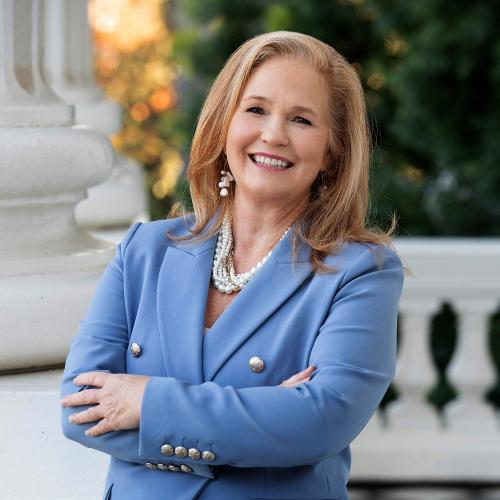

https://webapi.assembly.ca.gov/district-media/assets/members/assembly_member_28.jpg

# Part II: What does the evidence establish?

## AI across the campaign system

| Stage | Possible AI role |
| --- | --- |
| **Identify** | Organize voter and donor information |
| **Target** | Rank audiences and segment lists |
| **Generate** | Draft copy, visuals and translations |
| **Contact** | Assist email, text and chat outreach |
| **Fundraise** | Draft appeals and follow-up messages |
| **Iterate** | Analyze responses and revise the next approach |

Possible uses, not estimates of effectiveness

## Who gains from cheaper campaigning?

### Small and large campaigns

- Could cheaper production help small teams enter?
- Could data and distribution let large campaigns scale?

### Challengers and incumbents

- Could cheaper outreach help challengers become known?
- Do trust and name recognition still favor incumbents?

**More campaign activity: more persuasion, more action, or neither?**

Discussion hypotheses · Size and incumbency are different dimensions

## Which outcome are we measuring?

**Attitude**

- What someone reports believing or supporting

**Political action**

- What someone does

**Election result**

- What happens in an election

## What did these field experiments find?

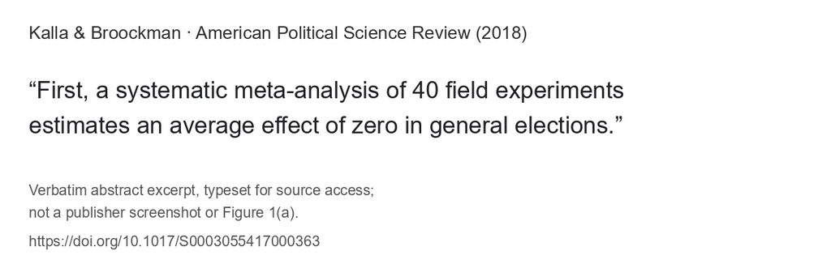

https://doi.org/10.1017/S0003055417000363

## What did the experiment compare?

Paid UK Prolific participants

Baseline attitudes → random assignment to petition and chat condition

**Treatment**

- AI instructed to persuade the participant to sign the assigned petition

**Control**

- Same chat interface; neutral-topic AI conversation

After the chat

- Attitudes measured again
- Opportunity to sign a real petition: name, email and completed submission

Hackenburg et al. (2026), working paper · https://arxiv.org/pdf/2604.09200

## Can an AI conversation lead to action?

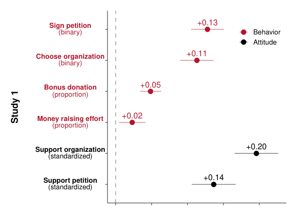

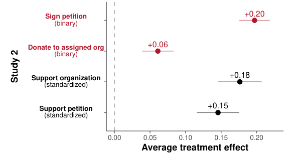

Figure 2; panels rearranged · https://arxiv.org/pdf/2604.09200

# Part III: Evaluate a rule

## How would this rule work?

1. Alone · 1 min: choose one rule discussed today
2. Pairs · 2 min: policy designer + implementation skeptic
3. Share · 2 min: one mechanism, one limit

**Target and mechanism**

**Enforcement**

**Trade-off**

Solo or written answers welcome

## What evidence would convince you a rule works?

**Campaign power**

Who gains capacity?

→

**Measured outcome**

What changes?

→

**Policy mechanism**

What could a rule change?

## See you next class

Thank you, Assemblymember Pellerin

Wednesday, October 21

Post-Training and Reasoning Models · Yiqing Xu